# Introducción a la Metodología Aplicada

2026

Dr. Manuel Mejía

manuel.mejia@cetys.mx

Escuela de Psicología, Campus Tijuana  
CETYS Universidad

# Encuadre

## Importancia de saber hacer proyectos

1. La neuropsicología es joven, y aún falta mucho por hacer. En particular en contextos no WEIRD.
2. Una maestría prepara para un doctorado.
3. Saber leer de manera crítica la literatura.
4. Las habilidades para hacer un proyecto académico son transferibles para proyectos en industria y asociaciones civiles.

## Competencia

[output not shown]

## Rúbrica de tutores

1. Mostrar rúbrica.
2. Resolver dudas.

## Actividad 1: keywords

1. Cómo se usan los “keywords” o “palabras clave” en las publicaciones científicas y en congresos.
2. Cuáles son keywords útiles.
3. Realizar actividad en Miro.

**Note**

Keywords need to be descriptive and capture the most important aspects of your paper. They are used for indexing in databases and as search terms for readers. Include three to five words, phrases, or acronyms as keywords.

## Actividad 2: presenta tu idea

1. Define tu proyecto en tres preguntas:
1. ¿Qué se ha hecho?
2. ¿Qué falta por hacer?
3. ¿Qué propones realizar?

## Tesis en 3 minutos

## JARS

https://www.dropbox.com/scl/fo/p83siv3sdhgi5ldk7qgz5/ACJrGtUto2BeioZ_u38BaGQ?rlkey=74ytirbulgp0r1m55pom4h9ow&dl=0

## Fuentes

[Biblioteca digital](https://koha.cetys.mx/cgi-bin/koha/opac-page.pl?page_id=56)

# ¿Qué es un anteproyecto?

## Anteproyecto o protocolo

**Es el plan razonado de una investigación que todavía no se ha realizado.**

- Explica **qué** queremos conocer y **por qué** importa.
- Propone **cómo** obtendremos evidencia para responder.
- Permite examinar la **coherencia y viabilidad** del estudio antes de iniciarlo.

> No presenta resultados obtenidos: anticipa las decisiones necesarias para obtenerlos.

## La estructura: una pregunta detrás de cada sección

```
%%{init: {
  "themeVariables": {
    "fontSize": "24px"
  },
  "flowchart": {
    "padding": 70
  }
}}%%
flowchart LR
  A["¿Qué sabemos<br/>y qué falta?<br/><b>Problema</b>"] --> B["¿Por qué<br/>importa?<br/><b>Justificación</b>"]
  B --> C["¿Cómo lo<br/>explicamos?<br/><b>Fundamento</b>"]
  C --> D["¿Qué queremos<br/>lograr?<br/><b>Objetivos</b>"]
  D --> E["¿Cómo reuniremos<br/>la evidencia?<br/><b>Metodología</b>"]
  E --> F["¿Cómo la<br/>interpretaremos?<br/><b>Análisis</b>"]
```

**Además:** título, resumen, referencias, cronograma, presupuesto y anexos.

## Título y resumen

### Título

- ¿Cuál es el **fenómeno central**?
- ¿En **quiénes** se estudiará?
- ¿Puede expresarse con **precisión y brevedad**?

### Resumen

- ¿Cuál es la **pregunta** y su importancia?
- ¿Qué **objetivo** persigue?
- ¿Qué **método** se propone?

> El título orienta; el resumen ofrece una vista completa del plan.

## 1. Planteamiento del problema

**Justifica científicamente la necesidad de investigar.**

1. ¿Qué se conoce sobre el fenómeno?
2. ¿Qué resultados son **insuficientes, contradictorios o inciertos**?
3. ¿Cuál es el **vacío de conocimiento** concreto?

Usualmente se enfatizan dos elementos clave:

- ¿Qué **pregunta** surge de ese vacío? Pregunta de investigación.
- ¿Cuáles son las expectativas de respuesta? Hipótesis de investigación.

**Secuencia:** evidencia disponible → vacío → pregunta investigable.

## 2. Justificación y uso de los resultados

**Explica para qué sería útil responder la pregunta.**

- ¿Qué conocimiento nuevo se espera producir?
- ¿A quién podría beneficiar: pacientes, familias, profesionales o instituciones?
- ¿Cómo podrían **utilizarse y difundirse** los hallazgos?

> **Distinción clave:** el problema muestra *qué falta saber*; la justificación explica *por qué vale la pena saberlo*.

## 3. Fundamento teórico

**Construye la explicación que da sentido a la pregunta.**

- ¿Qué conceptos y modelos explican el fenómeno?
- ¿Qué relaciones entre variables propone la literatura?
- ¿Qué hallazgos apoyan o cuestionan esas explicaciones?
- ¿Qué hipótesis se derivan, **si el tipo de estudio las requiere**?

**No es acumular citas:** es construir un argumento a partir de la evidencia.

## 4. Objetivos de investigación

### Objetivo general

**¿Qué conocimiento central queremos obtener?**

Describe el propósito del estudio mediante una acción: *describir, estimar, comparar, determinar…*

### Objetivos específicos

**¿Qué operaciones permiten cumplir el propósito general?**

Descomponen el objetivo en pasos relacionados y observables.

> Cada objetivo debe poder vincularse con evidencia y un procedimiento de análisis.

## 5. Metodología: diseño y participantes

- **Diseño:** ¿qué tipo de estudio permite responder la pregunta?
- **Población:** ¿a quiénes se refieren nuestras conclusiones?
- **Muestra:** ¿cómo seleccionaremos participantes y cuántos necesitaremos?
- **Criterios:** ¿quiénes podrán participar y quiénes no?
- **Validez:** ¿qué sesgos o variables de confusión debemos controlar?

**El diseño se elige según los objetivos, no al revés.**

## 5. Metodología: variables y procedimientos

### ¿Qué mediremos?

- Definiciones **operacionales** de las variables.
- Pruebas, escalas o registros elegidos.
- Evidencia de calidad de las mediciones.

### ¿Cómo lo haremos?

- Orden de las actividades.
- Quién aplicará los instrumentos y cuándo.
- Control de calidad y resguardo de datos.

> Decir «evaluaremos la memoria» es insuficiente: **¿con qué tarea, puntuación y procedimiento?**

## 5. Metodología: aspectos éticos

**¿Cómo protegeremos a las personas participantes?**

- Beneficios, riesgos y posibles molestias.
- Consentimiento informado y derecho a retirarse.
- Confidencialidad y manejo de información personal.
- Protección especial cuando existan condiciones de vulnerabilidad.
- Revisión por el comité de ética correspondiente.

## 6. Plan de análisis

**Explica cómo la evidencia responderá los objetivos.**

- ¿Qué datos y variables producirá el estudio?
- ¿Cómo se **describirán** los resultados?
- ¿Qué comparaciones, asociaciones o análisis se realizarán?
- ¿Qué técnicas son apropiadas para el diseño y tipo de datos?

> El análisis debe planearse **antes** de recolectar los datos.

## 7. Viabilidad y documentación

### Organización

- **Cronograma:** ¿cuánto tomará cada etapa?
- **Presupuesto:** ¿qué recursos se necesitarán?

### Soporte

- **Referencias:** ¿qué fuentes sustentan el plan?
- **Anexos:** ¿qué instrumentos o procedimientos conviene adjuntar?

*La guía OPS presenta una estructura orientativa que se adapta al tipo de estudio.*

## Un mismo ejemplo a lo largo del protocolo

**Ejemplo didáctico hipotético: sueño y memoria en adultos mayores**

| Sección | Una decisión posible |
| --- | --- |
| **Pregunta** | ¿Se asocia la calidad del sueño con el desempeño en memoria episódica en personas de 60 años o más? |
| **Objetivo** | Estimar la asociación entre ambas variables. |
| **Diseño** | Observacional, transversal. |
| **Mediciones** | Puntuación de sueño y puntuación de recuerdo diferido con instrumentos definidos. |
| **Análisis** | Describir las puntuaciones y estimar su asociación; considerar edad y escolaridad. |

La existencia de un vacío en la literatura y la elección de instrumentos deben verificarse antes de formular el protocolo definitivo. Una asociación transversal no demuestra causalidad.

## La regla de oro: coherencia interna

```
flowchart LR
  P["Pregunta"] --> O["Objetivo"] --> V["Variable o<br/>fenómeno"] --> M["Medición"] --> A["Análisis"]
```

**Preguntas de revisión:**

- ¿Cada objetivo responde una parte de la pregunta?
- ¿Cada variable o fenómeno tiene un modo de observarse?
- ¿Cada análisis aporta evidencia para un objetivo?

## Actividad inicial · Un anteproyecto en cinco líneas

**Piensa en un problema de neuropsicología y completa:**

1. Quiero estudiar **__________**.
2. Lo que todavía no está claro es **__________**.
3. Mi pregunta de investigación es **__________**.
4. Para responderla, observaría o compararía **__________**.
5. El conocimiento obtenido sería útil para **__________**.

**Meta:** salir de clase con una primera versión de la pregunta de investigación.

## Referencia y alcance

**Organización Panamericana de la Salud (OPS/OMS).** *Guía para escribir un protocolo / una propuesta de investigación*. Programa de Subvenciones para la Investigación.

- Presentación adaptada y sintetizada para **introducir** la estructura general del anteproyecto.
- La guía distingue problema, justificación, fundamento, objetivos, metodología, plan de análisis y elementos complementarios.
- Sus apartados son **orientativos**, no una plantilla rígida para todo diseño.

# Evaluar una idea: PICOT y FINER

## ¿Qué necesitamos al final de esta clase?

- Transformar un **problema clínico o teórico** en una pregunta investigable.
- Especificar sus componentes mediante **PICOT**.
- Evaluar su calidad y viabilidad mediante **FINER**.
- Formular un **objetivo** y una **hipótesis** coherentes con la pregunta.

**Note**

**Producto de la sesión:** una pregunta PICOT y una revisión FINER de un proyecto propio.

## Una buena idea todavía no es una pregunta investigable

```
flowchart LR
    A[Observación clínica<br/>o curiosidad teórica] --> B[Idea inicial]
    B --> C[Revisión de literatura<br/>y vacío de conocimiento]
    C --> D[Pregunta investigable]
    D --> E[Objetivos e hipótesis]
    P[PICOT] -. estructura .-> D
    F[FINER] -. evalúa .-> D
    D -. revisar .-> C
    classDef emphasis fill:#dceff7,stroke:#187a9d,color:#123247,stroke-width:2px;
    class D,P,F emphasis;
```

**Preguntas para comenzar:** ¿Qué observo? ¿Qué desconozco? ¿Qué evidencia falta? ¿Qué respuesta concreta podría obtener?

## Elaborar una pregunta

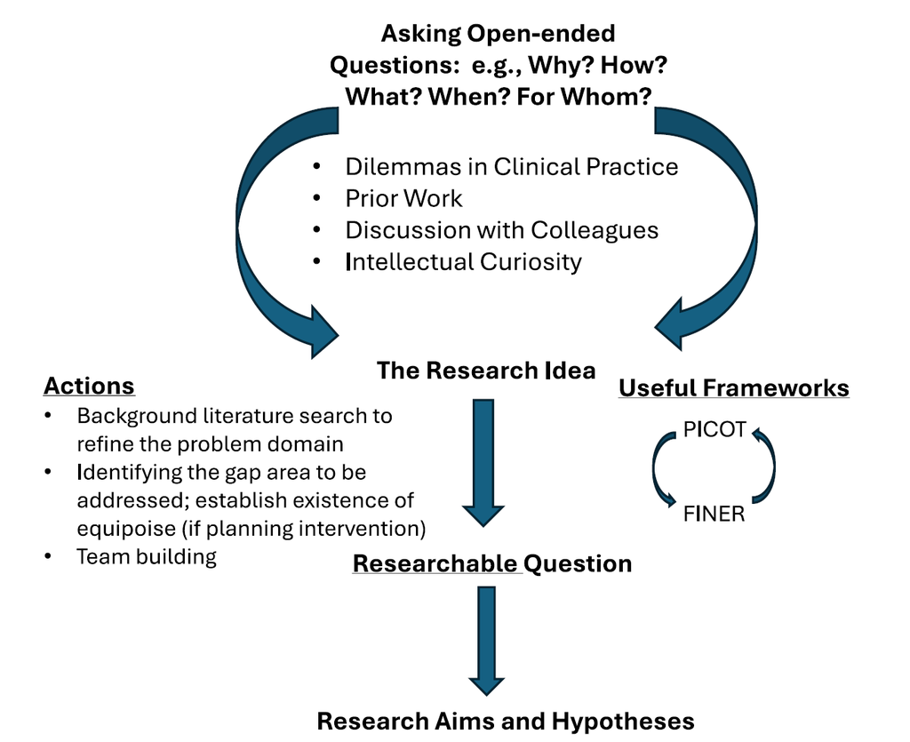

## PICOT

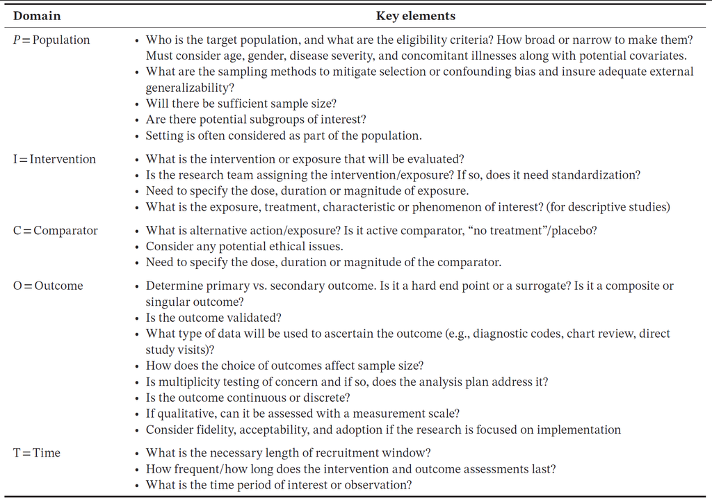

## FINER

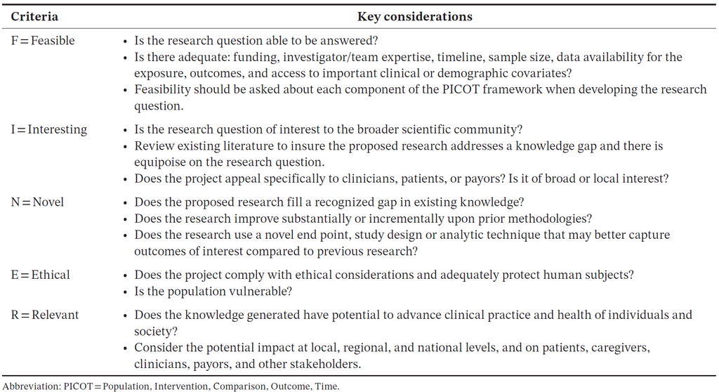

## De una inquietud a una pregunta

### Idea amplia

> “La rehabilitación cognitiva ayuda a mejorar la memoria.”

**Problemas:** ¿A quiénes? ¿Qué rehabilitación? ¿Comparada con qué? ¿Qué significa mejorar? ¿Cuándo?

### Pregunta delimitada

> “En adultos con lesión cerebral adquirida, ¿un entrenamiento de memoria de ocho semanas, comparado con la atención habitual, mejora el recuerdo diferido al finalizar el programa?”

## PICOT: anatomía de la pregunta

```
flowchart TB
    Q[Pregunta de investigación]
    P["P · Población<br/>¿En quiénes?"]
    I["I · Intervención / exposición<br/>¿Qué se estudia?"]
    C["C · Comparación<br/>¿Frente a qué?"]
    O["O · Resultado<br/>¿Qué se medirá?"]
    T["T · Tiempo<br/>¿Durante cuánto tiempo?"]
    P --> Q
    I --> Q
    C --> Q
    O --> Q
    T --> Q
    classDef question fill:#1f536b,color:white,stroke:#1f536b;
    class Q question;
```

**PICOT no es una secuencia temporal:** las cinco decisiones deben ser coherentes entre sí.

## P · Población: ¿a quién queremos comprender?

- ¿Cuál es la **población objetivo**?
- ¿Qué diagnóstico, edad, contexto o grado de afectación la caracteriza?
- ¿Cuáles son los criterios de **inclusión y exclusión**?
- ¿Dónde y cómo se reclutará a los participantes?
- ¿Quiénes quedarían fuera y cómo afecta eso la generalización?
- ¿Existen subgrupos relevantes o posibles variables de confusión?

### Ejemplo

**P:** Adultos de 30–65 años con lesión cerebral adquirida y dificultades de memoria documentadas.

**Delimitación:** pacientes ambulatorios, capaces de completar la evaluación.

## I · Intervención o exposición: ¿qué examinaremos?

- ¿La **asignará** el equipo investigador o simplemente la observará?
- ¿Qué componentes, intensidad, frecuencia y duración tendrá?
- ¿Cómo se documentará su aplicación o la exposición real?
- ¿Qué aspectos deben estandarizarse?

**Tip**

**En diseños no experimentales:** I puede significar *exposición, condición, característica o fenómeno de interés*, no necesariamente un tratamiento.

**Ejemplos:** entrenamiento de memoria; severidad de lesión; carga de sueño; conectividad funcional.

## C · Comparación: ¿respecto a qué?

```
flowchart LR
    A[Participantes] --> B[Intervención de interés]
    A --> C[Atención habitual / control activo<br/>o grupo sin exposición]
    B --> D[Contraste definido]
    C --> D
    D --> E[Diferencia o asociación<br/>en el resultado]
```

- ¿Cuál es la comparación **científicamente informativa**?
- ¿La comparación es ética y razonablemente equivalente?
- ¿Se pueden identificar factores que difieren entre grupos?
- ¿Existe una comparación necesaria o el estudio es puramente descriptivo?

## O · Resultado: ¿qué evidencia respondería la pregunta?

- ¿Cuál será el **resultado primario**?
- ¿Cómo se define de forma operacional?
- ¿Qué prueba o indicador ofrece evidencia válida y confiable?
- ¿Es una puntuación continua, una categoría o un evento?
- ¿Cuál sería una diferencia **clínicamente significativa**?
- ¿Qué resultados serán secundarios o exploratorios?

### Ejemplo

**Resultado primario:** cambio en la puntuación de recuerdo diferido de una prueba estandarizada.

**Secundario:** desempeño cotidiano informado mediante cuestionario funcional.

## T · Tiempo: ¿cuándo y durante cuánto?

```
flowchart LR
    A[Ingreso<br/>línea base] --> B[8 semanas<br/>intervención]
    B --> C[Evaluación<br/>postratamiento]
    C -. seguimiento opcional .-> D[3 meses<br/>retención]
```

- ¿Cuál es la duración de la intervención o exposición?
- ¿En qué momentos se evaluará el resultado?
- ¿Cuánto tiempo debe observarse para detectar el efecto esperado?
- ¿Durante qué periodo se reclutará la muestra?

**Distinción:** el periodo total del proyecto no equivale necesariamente al tiempo de observación de cada participante.

## PICOT completo: un ejemplo de neuropsicología

| Componente | Decisión del estudio |
| --- | --- |
| **P** | Adultos con lesión cerebral adquirida y dificultades de memoria |
| **I** | Programa estructurado de entrenamiento de memoria |
| **C** | Atención habitual |
| **O** | Cambio en recuerdo diferido (resultado primario) |
| **T** | Ocho semanas; mediciones basal y posterior |

**Pregunta:** ¿En adultos con lesión cerebral adquirida, un programa de entrenamiento de memoria de ocho semanas, en comparación con la atención habitual, produce una mayor mejoría del recuerdo diferido entre la evaluación basal y la posterior?

## ¿Y si nuestro estudio no es experimental?

### Estudio observacional

- **P:** adultos mayores sin demencia.
- **I:** niveles de actividad física habitual.
- **C:** mayor frente a menor actividad.
- **O:** puntuaciones de funciones ejecutivas.
- **T:** evaluación transversal.

**Lenguaje:** asociación, no efecto causal demostrado.

### Estudio descriptivo

- **P:** personas con esclerosis múltiple.
- **I:** dificultades cognitivas percibidas (fenómeno).
- **C:** puede no existir un comparador.
- **O:** frecuencia y características de las quejas.
- **T:** periodo de evaluación definido.

**PICOT se adapta a la pregunta; no se fuerza.**

## FINER: ¿vale la pena y podemos investigarla?

```
flowchart TB
    Q[Pregunta formulada con PICOT]
    F["F · Feasible<br/>Viable"]
    I["I · Interesting<br/>Interesante"]
    N["N · Novel<br/>Novedosa"]
    E["E · Ethical<br/>Ética"]
    R["R · Relevant<br/>Relevante"]
    Q --> F
    Q --> I
    Q --> N
    Q --> E
    Q --> R
    F & I & N & E & R --> V[Revisar, delimitar o avanzar]
    V -. retroalimentación .-> Q
    classDef key fill:#1f536b,stroke:#1f536b,color:white;
    class Q,V key;
```

## F · Viable: ¿podemos responderla?

- ¿Podemos obtener el **tamaño de muestra** requerido?
- ¿Tenemos acceso a pacientes, expedientes o bases de datos?
- ¿Disponemos de instrumentos, personal, capacitación y equipos?
- ¿Alcanza el presupuesto y el tiempo?
- ¿Las mediciones son técnicamente posibles y suficientemente precisas?
- ¿Podemos controlar o medir las variables de confusión principales?

**Note**

**Regla útil:** verificar la viabilidad de **cada componente de PICOT**, no solamente del proyecto en general.

## I · Interesante: ¿a quién le importa la respuesta?

- ¿Es una incertidumbre genuina para el equipo investigador?
- ¿Interesa a otros investigadores, profesionales o pacientes?
- ¿Existe debate, incertidumbre o evidencia contradictoria?
- ¿El resultado podría motivar nuevas investigaciones?

**Pregunta de discusión:** si encontramos un resultado nulo, ¿seguiría siendo informativo?

## N · Novedosa: ¿qué conocimiento agregamos?

```
flowchart LR
    A[Lo que ya sabemos] --> B[Vacío / limitación]
    B --> C[Contribución propuesta]
    C --> D[Conocimiento nuevo]
```

- ¿Qué estudios han respondido preguntas similares?
- ¿Qué aspecto permanece incierto?
- ¿Proponemos otra población, medida, diseño o análisis?
- ¿La mejora metodológica puede descubrir algo antes inaccesible?
- ¿La contribución es sustantiva y no solamente “usar una técnica nueva”?

**En neuropsicología:** una nueva medida neurofisiológica puede ser novedosa si responde una pregunta no resuelta.

## E · Ética: ¿deberíamos hacer este estudio?

- ¿Se justifican los riesgos frente al valor esperado?
- ¿Cómo garantizaremos consentimiento informado, privacidad y confidencialidad?
- ¿Trabajamos con una población vulnerable o con alteraciones en la capacidad de decisión?
- ¿Existe **incertidumbre clínica razonable** cuando asignamos tratamientos?
- ¿Se minimiza la carga de evaluación, fatiga o malestar?
- ¿Se requiere revisión y aprobación por un comité de ética?

**No basta con que sea técnicamente posible: debe ser éticamente justificable.**

## R · Relevante: ¿qué cambiaría con la respuesta?

### Relevancia científica

- ¿Modifica o fortalece una explicación de procesos cognitivos?
- ¿Mejora la interpretación de medidas o mecanismos neurales?
- ¿Permite formular mejores hipótesis?

### Relevancia aplicada

- ¿Mejora decisiones de evaluación o intervención?
- ¿Beneficia a pacientes, familias o profesionales?
- ¿Permite orientar recursos o desarrollar mejores servicios?

**Distinción:** lo novedoso no siempre es relevante, y lo relevante no siempre requiere una técnica novedosa.

## PICOT y FINER trabajan juntos

```
flowchart LR
    A[Idea inicial] --> B[Definir PICOT]
    B --> C[Evaluar FINER]
    C --> D{"¿Pregunta defendible?"}
    D -->|No| B
    D -->|Sí| E[Pregunta final]
    E --> F[Objetivos]
    F --> G[Hipótesis y método]
```

**Ejemplos de iteración:** muestra insuficiente → ajustar P; comparación no ética → redefinir C; prueba sin validez suficiente → reconsiderar O.

## De la pregunta a los objetivos e hipótesis

### Pregunta

¿El entrenamiento de memoria mejora el recuerdo diferido frente a la atención habitual?

### Objetivo

**Comparar** el cambio en recuerdo diferido entre ambos grupos después de ocho semanas.

### Hipótesis de investigación

La mejoría media en recuerdo diferido será mayor en el grupo de entrenamiento que en el de atención habitual.

### Pregunta de verificación

¿Podemos identificar el diseño, la variable independiente y la dependiente?

## Actividad en equipos · Construyan su PICOT

**Caso:** En consulta se observa que algunas personas con enfermedad de Parkinson experimentan dificultades ejecutivas que afectan sus actividades cotidianas.

1. Redacten una **pregunta concreta**.
2. Definan P, I, C, O y T. Cuando corresponda, adapten I a *exposición*.
3. Señalen el resultado primario y cómo lo medirían.
4. Expliciten qué tipo de estudio podrían realizar.

**Tiempo sugerido:** 8–10 minutos. Deben justificar cada decisión.

## Actividad · Auditoría FINER de su propuesta

| Criterio | Pregunta crítica | Decisión / ajuste |
| --- | --- | --- |
| **F** | ¿Podemos obtener los datos y la muestra? |  |
| **I** | ¿A quién interesa la respuesta? |  |
| **N** | ¿Cuál es el vacío de conocimiento? |  |
| **E** | ¿Cómo protegemos a participantes? |  |
| **R** | ¿Qué aportación concreta tendría? |  |

**Desafío:** identifiquen el criterio más débil y modifiquen su PICOT para fortalecerlo.

## Lista de comprobación antes de comenzar

- ¿La pregunta puede expresarse en **una sola oración clara**?
- ¿P, I, C, O y T son explícitos o se justifica alguna adaptación?
- ¿El resultado primario es operacionalizable y pertinente?
- ¿La pregunta supera una evaluación FINER razonable?
- ¿El objetivo y la hipótesis realmente responden a esa pregunta?

**Tip**

**Idea clave:** un buen método comienza con una buena pregunta, no con una base de datos o una técnica disponible.

## Referencia principal

Ernst, M. E., & Cochran, G. L. (2025). Research and scholarly methods: Research ideas, questions, and aims. *Journal of the American College of Clinical Pharmacy, 8*, 1194–1201. https://doi.org/10.1002/jac5.70095

**Adaptación didáctica:** diagramas y ejemplos de neuropsicología elaborados para esta presentación, a partir de los marcos descritos en el artículo (tablas 1 y 2; figuras 1 y 2).

# Visión moderna de la ciencia

## Ciencia moderna: más allá del “un estudio prueba una teoría”

### Idea central

- En la ciencia actual, **un solo estudio rara vez “prueba” o “desprueba”** una hipótesis o teoría.
- Lo que evaluamos no es una afirmación aislada, sino un **conjunto** de:
  - hipótesis principales,
  - supuestos auxiliares,
  - decisiones de medición,
  - condiciones del diseño,
  - y marcos teóricos más amplios.

### Tres autores clave

- **W.V.O. Quine**: las hipótesis se contrastan **en red**, no una por una.
- **Imre Lakatos**: las teorías funcionan como **programas de investigación** con un núcleo central y un cinturón protector.
- **Paul Meehl**: el progreso científico exige **predicciones arriesgadas, precisión teórica y acumulación de evidencia**, no explicaciones ad hoc tras cada resultado.

## Implicación metodológica

> Un estudio aporta evidencia,  
> **pero su valor depende del patrón acumulado de resultados**.

**Entonces, la pregunta no es:**

- “¿Esta teoría quedó probada?”

**Sino más bien:**

- “¿Qué tan bien explica esta teoría el conjunto de la evidencia?”
- “¿Explica más que sus alternativas?”
- “¿Predice hallazgos nuevos?”
- “¿Resiste intentos serios de refutación?”

**Note**

La ciencia progresa por contraste entre explicaciones rivales y por acumulación de evidencia convergente.

## Duhem–Quine: ninguna hipótesis se prueba sola

```
flowchart LR
    H["Hipótesis principal<br/>Ej.: el entrenamiento mejora la memoria"] --> P["Predicción observable<br/>Mejor puntuación postest"]
    A1["Supuesto auxiliar 1<br/>La intervención se aplicó correctamente"] --> P
    A2["Supuesto auxiliar 2<br/>La muestra es adecuada"] --> P
    A3["Supuesto auxiliar 3<br/>La prueba mide memoria de forma válida"] --> P
    A4["Supuesto auxiliar 4<br/>No hubo sesgos o factores de confusión graves"] --> P
    P --> R{"¿Se observó el resultado esperado?"}
    R -->|Sí| S["La evidencia favorece<br/>al conjunto de hipótesis y auxiliares"]
    R -->|No| N["Hay un problema en el conjunto:<br/>¿hipótesis o supuestos auxiliares?"]

    classDef key fill:#dceff7,stroke:#187a9d,color:#123247,stroke-width:2px;
    class P,R key;
```

$$(H \land A_1 \land A_2 \land A_3 \land A_4) \Rightarrow E$$

$$\neg E \Rightarrow \neg(H \land A_1 \land A_2 \land A_3 \land A_4)$$

## Idea clave

- Un resultado negativo **no autoriza automáticamente** concluir que la hipótesis principal es falsa.
- El problema puede estar en la teoría, un supuesto auxiliar, la medición, la muestra o el diseño.
- Por eso la ciencia necesita **series de estudios**, mejoras metodológicas y comparación entre explicaciones rivales.

**Note**

En neuropsicología, un hallazgo nulo puede deberse a la teoría, pero también a baja potencia, tareas poco sensibles o heterogeneidad clínica.

## ¿Cómo progresa realmente la ciencia?

### Lakatos: programas de investigación

- Una teoría suele formar parte de un **programa de investigación**.
- Ese programa tiene:
  - **Núcleo duro**: compromisos centrales que no se abandonan ante un solo resultado.
  - **Cinturón protector**: hipótesis auxiliares que sí pueden revisarse.
- Un programa es **progresivo** cuando explica evidencia previa y anticipa hallazgos nuevos que reciben apoyo empírico.
- Es **degenerativo** cuando predominan los ajustes retrospectivos sin predicciones nuevas corroboradas.

### Paul Meehl

- La ciencia mejora cuando formula **predicciones más precisas y arriesgadas**.
- No basta con obtener un resultado estadísticamente significativo.
- Importan la **consiliencia**, la **replicación**, la comparación entre teorías rivales y la reducción de explicaciones *ad hoc*.

## Cómo deberíamos razonar

| Un solo estudio | Evaluación científica más sólida |
| --- | --- |
| “Confirmó” | **Aportó evidencia compatible** |
| “Refutó” | **Contradice o contrasta con** |
| “Funcionó/no funcionó” | **Se integra con otros estudios** |
| “Teoría correcta” | **Mejor explicación disponible hasta ahora** |

- La ciencia no es una mera colección de hechos o veredictos…
  - Es un proceso de **acumulación de evidencia**, **revisión crítica**, **comparación de explicaciones** y **juicio racional**.

> Si un estudio contradice una hipótesis, ¿qué cambiarías primero: la teoría, los auxiliares, la medida o el diseño?

# Enfoques de investigación: cuantitativo, cualitativo y mixto

**Introducción a la Metodología Aplicada · Neuropsicología**

*Basado en Hernández Sampieri, Fernández Collado y Baptista Lucio (2014), capítulo 1.*

## ¿Qué aprenderemos?

- Reconocer qué comparten la investigación **cuantitativa** y la **cualitativa**.
- Distinguir sus preguntas, procesos, datos y formas de análisis.
- Identificar cuándo conviene usar uno u otro enfoque, o combinarlos.

## ¿Qué significa investigar?

> La investigación aplica procesos **sistemáticos, críticos y empíricos** al estudio de fenómenos y problemas.

Los dos enfoques comparten una lógica general:

1. Observar y evaluar fenómenos.
2. Formular ideas o explicaciones.
3. Examinar sus fundamentos.
4. Revisarlas a partir de la evidencia.
5. Plantear nuevas observaciones o preguntas.

## Ambos enfoques constituyen investigación científica

| Cuantitativo | Cualitativo |
| --- | --- |
| Busca **medir**, comparar y estimar relaciones. | Busca **comprender** experiencias, procesos y significados. |
| Planteamientos habitualmente acotados. | Planteamientos que pueden afinarse durante el estudio. |
| Datos principalmente numéricos. | Datos principalmente narrativos, observacionales y simbólicos. |

**Ambos** utilizan procedimientos sistemáticos y empíricos para generar conocimiento.

Enfoque cuantitativo

## El enfoque cuantitativo: ¿cuánto?, ¿qué relación?, ¿qué efecto?

- Define variables y preguntas específicas.
- Habitualmente formula hipótesis **antes** de recolectar datos.
- Utiliza mediciones y procedimientos estandarizados.
- Analiza datos numéricos mediante estadística.
- Busca estimar patrones, contrastar hipótesis y, cuando procede, generalizar resultados.

## Proceso cuantitativo: secuencial y probatorio

```
flowchart LR
    A["Idea"] --> B["Problema"]
    B --> C["Literatura y teoría"]
    C --> D["Hipótesis y variables"]
    D --> E["Diseño y muestra"]
    E --> F["Medición y análisis"]
    F --> G["Conclusiones"]
```

**Idea central:** las decisiones de diseño y medición se fundamentan en una pregunta previamente delimitada. El proceso puede revisarse cuando sea necesario.

## Ejemplo cuantitativo en neuropsicología

**Idea:** el sueño podría relacionarse con el rendimiento en memoria.

- **Pregunta:** ¿Existe asociación entre calidad del sueño y recuerdo diferido en adultos mayores?
- **Variables:** calidad del sueño y puntuación de recuerdo diferido.
- **Datos:** cuestionario y prueba neuropsicológica estandarizada.
- **Análisis:** estimación de la asociación y consideración de variables de confusión.

**Pregunta para el grupo:** ¿Qué debemos definir *antes* de recolectar datos?

Enfoque cualitativo

## El enfoque cualitativo: ¿cómo se vive?, ¿qué significa?, ¿por qué?

- Investiga experiencias, interpretaciones e interacciones.
- Suele estudiar los fenómenos en su **contexto natural**.
- Utiliza preguntas abiertas y procedimientos flexibles.
- Las preguntas y categorías pueden redefinirse durante el trabajo de campo.
- Busca comprensión profunda y riqueza contextual, no necesariamente generalización estadística.

## Proceso cualitativo: flexible e iterativo

```
flowchart LR
    A["Idea y pregunta inicial"] --> B["Inmersión en el contexto"]
    B --> C["Participantes y datos"]
    C --> D["Análisis e interpretación"]
    D --> E["Comprensión y reporte"]
    D --> B
    D --> C
```

**Idea central:** recolección, análisis e interpretación pueden desarrollarse de forma simultánea y retroalimentarse.

## Ejemplo cualitativo en neuropsicología

**Idea:** conocer cómo se experimenta la rehabilitación después de un accidente cerebrovascular.

- **Pregunta inicial:** ¿Cómo describen los pacientes los cambios en su vida cotidiana después de iniciar rehabilitación cognitiva?
- **Datos:** entrevistas abiertas, observaciones y relatos.
- **Análisis:** identificación e interpretación de temas recurrentes y divergentes.
- **Posible ajuste:** incorporar a familiares si sus relatos revelan una dimensión relevante.

**Pregunta para el grupo:** ¿Qué información perderíamos si utilizáramos únicamente una escala?

## Comparación 1: ¿cómo se plantea el estudio?

| Dimensión | Cuantitativo | Cualitativo |
| --- | --- | --- |
| **Pregunta** | Específica y delimitada | Abierta; puede enfocarse progresivamente |
| **Lógica predominante** | Deductiva | Inductiva |
| **Hipótesis** | Generalmente previas | Pueden emerger durante el estudio |
| **Diseño** | Estructurado desde el inicio | Flexible y sensible al contexto |

*Son tendencias de los enfoques, no reglas sin excepciones.*

## Comparación 2: ¿cómo se generan los datos?

| Dimensión | Cuantitativo | Cualitativo |
| --- | --- | --- |
| **Muestra** | Según población, precisión y análisis previstos | Según casos relevantes y profundidad de comprensión |
| **Recolección** | Pruebas, escalas y registros estandarizados | Entrevistas, observaciones, documentos |
| **Análisis** | Estadístico, centrado en variables | Interpretativo y temático, centrado en experiencias |
| **Resultado** | Estimaciones, relaciones, modelos | Temas, descripciones y explicaciones contextualizadas |

## ¿Cuál es el papel del investigador?

**En el enfoque cuantitativo**

- Busca minimizar sesgos y errores de medición.
- Procura procedimientos consistentes y replicables.

**En el enfoque cualitativo**

- Reconoce que su presencia e interpretación forman parte del proceso.
- Documenta decisiones, perspectivas y contexto.

**En ambos:** el rigor y la transparencia son indispensables.

## ¿Qué se considera una buena evidencia?

| Cuantitativo | Cualitativo |
| --- | --- |
| Validez de las mediciones | Credibilidad de las interpretaciones |
| Confiabilidad y precisión | Coherencia y sustento en los datos |
| Control de sesgos | Reflexividad y consideración de perspectivas |
| Alcance de la generalización | Transferibilidad a otros contextos |

**El criterio depende de lo que pretendemos conocer.**

## Mismo fenómeno, preguntas distintas

**Fenómeno:** dificultades cognitivas después de un accidente cerebrovascular.

| Cuantitativo | Cualitativo |
| --- | --- |
| ¿Cuánto cambia la memoria a los seis meses? | ¿Cómo describen las personas los cambios en su memoria? |
| Pruebas y puntuaciones repetidas. | Entrevistas y relatos de la vida cotidiana. |
| Estima magnitud y trayectoria del cambio. | Comprende significados e implicaciones del cambio. |

**No compiten:** responden preguntas diferentes sobre un mismo fenómeno.

## ¿Y los métodos mixtos?

- Combinan estrategias cuantitativas y cualitativas en una misma investigación.
- Permiten abordar **magnitudes** y **experiencias** del fenómeno.
- La integración debe responder a una pregunta que se beneficie de ambas fuentes de evidencia.

**Ejemplo:** medir cambios cognitivos tras una intervención **y** entrevistar a pacientes sobre su impacto cotidiano.

## ¿Cómo elegir el enfoque?

| Si queremos… | Podemos priorizar… |
| --- | --- |
| Estimar prevalencia, cambios o asociaciones | Cuantitativo |
| Comprender significados y experiencias | Cualitativo |
| Integrar efectos medidos con experiencias vividas | Mixto |

**No elegir por preferencia personal:** elegir según la pregunta, el contexto y los recursos.

## Identifica el enfoque

**A.** ¿Se asocia la fragmentación del sueño con la velocidad de procesamiento en adultos mayores?

**B.** ¿Qué significado atribuyen las familias al diagnóstico de demencia de uno de sus integrantes?

**C.** ¿Cuánto mejora una intervención de memoria y cómo perciben los pacientes sus resultados?

Discusión:

1. ¿Cuál enfoque conviene para cada pregunta?
2. ¿Qué datos recolectarían y con qué instrumentos?
3. ¿Qué tipo de conclusión podrían sostener?

## Una precaución: no confundir enfoque con diseño

- **Cuantitativo** no significa necesariamente **experimental**: también puede ser descriptivo, correlacional o longitudinal.
- **Cualitativo** no significa simplemente hacer una entrevista: requiere un diseño de indagación y análisis sistemático.
- **Mixto** no significa añadir una pregunta abierta a una encuesta: requiere integración justificada de los enfoques.

## Para cerrar

**La pregunta de investigación guía la elección del enfoque.**

- Medir y contrastar → énfasis cuantitativo.
- Explorar y comprender → énfasis cualitativo.
- Integrar ambas perspectivas → enfoque mixto.

**Pregunta:** ¿Cómo cambiaría tu anteproyecto si quisieras comprender el fenómeno, en lugar de solamente medirlo?

## Referencia

Hernández Sampieri, R., Fernández Collado, C. y Baptista Lucio, P. (2014). *Metodología de la investigación* (6.ª ed.). McGraw-Hill. Capítulo 1: «Definiciones de los enfoques cuantitativo y cualitativo, sus similitudes y diferencias» (pp. 2–18).

*Los ejemplos de neuropsicología y las preguntas didácticas fueron elaborados para esta clase; no corresponden a estudios reportados en el capítulo.*

## Del tema al problema de investigación

**Planteamiento cuantitativo del problema**

- Una idea general no es todavía una pregunta investigable.
- **Plantear el problema** es delimitar qué se estudiará, en quiénes y cómo podría observarse o medirse.
- El planteamiento orienta las decisiones metodológicas del proyecto.

*Hernández Sampieri et al. (2014), capítulo 3.*

## Los cinco elementos del planteamiento

```
flowchart LR
    A["Idea inicial"] --> B["Objetivos"]
    B --> C["Preguntas"]
    C --> D["Justificación"]
    D --> E["Viabilidad"]
    E --> F["Vacíos de conocimiento"]
    F --> G["Problema delimitado"]
```

| Elemento | Pregunta guía |
| --- | --- |
| **Objetivos** | ¿Qué queremos lograr o conocer? |
| **Preguntas** | ¿Qué necesitamos responder? |
| **Justificación** | ¿Por qué vale la pena hacerlo? |
| **Viabilidad** | ¿Podemos realizarlo? |
| **Vacíos de conocimiento** | ¿Qué falta por saber? |

Los elementos **se relacionan entre sí**; el orden del diagrama es didáctico, no una secuencia inflexible.

## ¿Qué caracteriza a un buen problema cuantitativo?

- **Delimitado:** población, variables y contexto definidos.
- **Claro:** formulado sin términos ambiguos.
- **Empírico:** permite obtener evidencia observable o medible.
- **Investigable:** se puede responder con procedimientos científicos.

**Preguntas para revisar la idea:**

- ¿Qué conceptos o variables estudiaré?
- ¿Con qué participantes, dónde y cuándo?
- ¿Qué datos permitirían responder la pregunta?

## De una idea amplia a una pregunta precisa

```
flowchart TD
    A["Tema: sueño y cognición"] --> B["Proceso: memoria episódica"]
    B --> C["Población: adultos de 60 a 75 años"]
    C --> D["Variables: fragmentación del sueño y recuerdo diferido"]
    D --> E["Pregunta investigable"]
```

**Antes:** ¿Cómo afecta el sueño a la memoria?

**Después:** ¿Se relaciona la fragmentación del sueño con el recuerdo diferido en adultos de 60 a 75 años?

*La segunda pregunta estudia una asociación; no presupone causalidad.*

## Objetivos y preguntas: deben corresponderse

| Objetivo de investigación | Pregunta correspondiente |
| --- | --- |
| **Describir** el rendimiento de memoria en un grupo. | ¿Cómo se distribuyen las puntuaciones de memoria? |
| **Comparar** el recuerdo diferido de dos grupos. | ¿Difieren los grupos en recuerdo diferido? |
| **Relacionar** fragmentación del sueño y memoria. | ¿Existe asociación entre ambas variables? |

**Para redactarlos:**

- Objetivo: verbo de investigación + variables + población.
- Pregunta: expresar la misma intención en forma interrogativa.
- Evitar objetivos tan amplios que impliquen varios estudios.

## Justificación: ¿por qué investigar esto?

| Criterio | Pregunta para el anteproyecto |
| --- | --- |
| **Conveniencia** | ¿Para qué sirve este estudio? |
| **Relevancia social** | ¿Quién podría beneficiarse? |
| **Implicaciones prácticas** | ¿Qué problema ayudaría a atender? |
| **Valor teórico** | ¿Qué conocimiento o explicación ampliaría? |
| **Utilidad metodológica** | ¿Mejoraría instrumentos, medidas o procedimientos? |

**Importante:** no es necesario cumplir todos los criterios, pero sí justificar de forma convincente la aportación esperada.

## Viabilidad: una buena pregunta debe poder estudiarse

- **Participantes:** ¿hay acceso a la población y un número suficiente de casos?
- **Recursos:** ¿se dispone de instrumentos, personal y presupuesto?
- **Tiempo:** ¿es posible reclutar, medir y analizar en el plazo previsto?
- **Contexto:** ¿hay acceso y permisos para trabajar en el lugar elegido?

**Ejemplo en neuropsicología:** un seguimiento a 10 años puede ser valioso, pero quizá inviable para una tesis de maestría.

## Vacíos de conocimiento y consecuencias

### ¿Qué se desconoce?

- ¿Qué sabemos por estudios previos?
- ¿Qué resultados son contradictorios?
- ¿Qué población o variable falta estudiar?
- ¿Qué nueva perspectiva aportaría el proyecto?

### ¿Qué consecuencias tendría?

- ¿Existen riesgos o cargas para los participantes?
- ¿Cómo se protegerían sus datos?
- ¿Se justifica éticamente la investigación?
- ¿Qué implicaciones podrían tener los resultados?

*El vacío se establece después de revisar antecedentes; no debe asumirse solo porque el tema parece novedoso.*

## Tipos de planteamiento según su propósito

| Propósito | Ejemplo neuropsicológico |
| --- | --- |
| **Explorar** | Identificar variables poco estudiadas asociadas a las quejas de memoria. |
| **Describir** | Caracterizar el rendimiento ejecutivo en pacientes con TCE leve. |
| **Relacionar** | Estimar la asociación entre fatiga y velocidad de procesamiento. |
| **Explicar / evaluar efectos** | Comparar el efecto de dos intervenciones sobre el recuerdo diferido. |

**La pregunta debe ser congruente con lo que el diseño puede demostrar.** Una asociación observacional no establece, por sí sola, causalidad.

## Errores frecuentes al plantear un problema

| Evitar | Mejorar con… |
| --- | --- |
| “Estudiar la cognición en adultos mayores”. | Variables, población y contexto concretos. |
| “Aplicar el MoCA a 50 personas”. | Un objetivo de conocimiento, no una actividad de recolección. |
| “Mejorar la calidad de vida de pacientes”. | Una pregunta evaluable; el beneficio esperado va en la justificación. |
| Muchos objetivos sin relación entre sí. | Una pregunta central y objetivos congruentes. |

**Regla práctica:** cada objetivo debe aportar a responder el problema central.

## Cómo redactarlo en el anteproyecto

**Guion breve del planteamiento cuantitativo:**

1. **Propósito:** “Este estudio pretende…”
2. **Pregunta y objetivo:** ¿qué se desea responder y conocer?
3. **Justificación:** ¿qué aportará y por qué importa?
4. **Vacío:** ¿qué falta en la evidencia previa?
5. **Viabilidad y consecuencias:** ¿es posible y éticamente adecuado?

**Ejemplo de apertura:**

> Este estudio pretende estimar la asociación entre la fragmentación del sueño y el rendimiento en recuerdo diferido en adultos de 60 a 75 años, mediante una evaluación transversal.

## Actividad: delimitar la pregunta de tu anteproyecto

**Idea inicial:** “Quiero estudiar la atención en personas con daño cerebral”.

**En equipos o individualmente (10–15 min):**

1. Elegir **un proceso** específico y **una población** concreta.
2. Formular **una pregunta empírica** y **un objetivo** congruente.
3. Escribir una justificación de **dos frases**.
4. Señalar **una limitación de viabilidad** y **un vacío** por verificar en la literatura.

**Discusión:** ¿qué decisiones metodológicas quedaron definidas al precisar la pregunta?

## Ideas que deben quedar claras

- **Plantear el problema** es pasar de una idea a una pregunta delimitada y respondible.
- **Objetivos y preguntas** deben corresponderse.
- **Justificación, viabilidad y vacíos** determinan la relevancia y el alcance del proyecto.
- Un planteamiento claro facilita elegir el **diseño, la muestra, las medidas y el análisis**.

**Fuente:** Hernández Sampieri, R., Fernández Collado, C., y Baptista Lucio, P. (2014). *Metodología de la investigación* (6.ª ed.), capítulo 3: “Planteamiento cuantitativo del problema”, pp. 34–57. McGraw-Hill.

Los ejemplos neuropsicológicos son elaboraciones didácticas, no resultados del libro.

# Alcances de la investigación cuantitativa

Exploratorio · Descriptivo · Correlacional · Explicativo

**Pregunta de la clase:** ¿Hasta dónde pretendemos llegar en el conocimiento de un fenómeno?

*Basado en Hernández Sampieri et al. (2014), cap. 5, pp. 88–101. Ejemplos neuropsicológicos desarrollados para clase.*

## ¿Qué significa «alcance» de una investigación?

El **alcance** indica **qué tipo de conocimiento** buscamos obtener sobre un fenómeno.

- **Explorar:** familiarizarnos con lo poco conocido.
- **Describir:** caracterizar el fenómeno y sus dimensiones.
- **Correlacionar:** establecer cómo se relacionan las variables.
- **Explicar:** investigar por qué ocurre y bajo qué condiciones.

**No es lo mismo que** el enfoque (cuantitativo/cualitativo), el diseño (experimental/observacional) o la temporalidad (transversal/longitudinal).

## Los cuatro alcances: un continuo

```
flowchart LR
    A["Exploratorio"] --> B["Descriptivo"]
    B --> C["Correlacional"]
    C --> D["Explicativo"]
```

| Alcance | Pregunta central |
| --- | --- |
| **Exploratorio** | ¿Qué hay aquí? ¿Qué convendría estudiar? |
| **Descriptivo** | ¿Cómo es? ¿Cuánto ocurre? |
| **Correlacional** | ¿Con qué se relaciona? ¿En qué magnitud? |
| **Explicativo** | ¿Por qué ocurre? ¿Qué lo produce? |

**Importante:** no son cuatro pasos obligatorios ni una jerarquía de calidad. Un estudio puede combinar alcances.

## El alcance guía el resto del protocolo

```
flowchart TB
    P["Problema y pregunta"] --> R["Revisión de literatura"]
    R --> A["Definir alcance tentativo"]
    A --> D["Diseño y muestra"]
    A --> M["Variables y mediciones"]
    A --> N["Plan de análisis"]
    D --> V["Viabilidad y revisión"]
    M --> V
    N --> V
```

**Discusión:** ¿Tiene sentido elegir una prueba estadística antes de saber qué queremos conocer?

## 1. Alcance exploratorio: ¿qué estamos descubriendo?

**Propósito:** examinar un tema poco estudiado, novedoso o abordado desde una perspectiva nueva.

- No conocemos todavía bien **qué variables o fenómenos** son relevantes.
- Las preguntas iniciales pueden ser más abiertas.
- Buscamos identificar aspectos prometedores para estudios posteriores.
- Se caracteriza por **mayor flexibilidad** y más incertidumbre metodológica.

**No equivale a:** «investigación improvisada» ni necesariamente «investigación cualitativa».

## ¿Cuándo conviene un alcance exploratorio?

- Hay pocos antecedentes aplicables a la población o al contexto.
- Los conceptos o medidas todavía necesitan clarificarse.
- Existe un fenómeno nuevo o una forma innovadora de estudiarlo.
- Queremos evaluar qué preguntas y variables son relevantes.

**Valor:** familiarización, nuevas hipótesis, variables promisorias y prioridades de investigación.

**Límite:** normalmente aún no permite conclusiones sólidas sobre prevalencia, asociaciones o causas.

## Ejemplo exploratorio en neuropsicología

**Tema:** uso de tareas de reconocimiento facial en realidad virtual para evaluar pacientes con dificultades perceptivas.

**Pregunta:** ¿Qué aspectos del desempeño y qué dificultades de aplicación aparecen al utilizar estas tareas en una muestra clínica inicial?

- **Participantes:** pequeño grupo clínico intencional.
- **Observaciones:** comprensión de instrucciones, patrones de error, tolerancia, problemas técnicos.
- **Producto:** variables e hipótesis para un estudio posterior.

**No concluiríamos todavía:** «la prueba diagnostica correctamente» o «la realidad virtual mejora la percepción».

## 2. Alcance descriptivo: ¿cómo es el fenómeno?

**Propósito:** especificar propiedades, características, perfiles o tendencias.

- **Define** qué dimensiones o variables serán observadas.
- **Mide y resume** esas dimensiones por separado o conjuntamente.
- Describe una población, grupo, proceso o situación concreta.

**Importante:** incluir varias variables no convierte automáticamente un estudio en correlacional.

## ¿Qué debemos definir para describir bien?

| Decisión | Pregunta que debe responder el protocolo |
| --- | --- |
| **Unidad de análisis** | ¿Personas, pruebas, sesiones, clínicas? |
| **Población** | ¿De quiénes queremos describir el fenómeno? |
| **Variables** | ¿Qué dominios o características mediremos? |
| **Instrumentos** | ¿Cómo obtendremos puntuaciones interpretables? |
| **Indicadores** | ¿Medias, dispersión, porcentajes, distribuciones? |

**Precaución:** describir una muestra clínica no implica que sea representativa de toda la población.

## Ejemplo descriptivo: perfil después de un TCE leve

**Pregunta:** ¿Cómo se distribuye el desempeño en memoria, atención y funciones ejecutivas en adultos atendidos tres a seis meses después de un TCE leve?

- Medir puntuaciones por dominio en **los mismos participantes**.
- Reportar medias, medianas, dispersión y proporciones bajo un criterio explícito.
- Describir los dominios con mayores dificultades en **esa muestra**.

**No responde por sí solo:** ¿la atención baja *causa* la dificultad de memoria? ¿La edad se asocia al desempeño?

## Describir variables ≠ relacionarlas

**Tenemos dos medidas en los mismos pacientes:** fatiga percibida y velocidad de procesamiento.

| Alcance descriptivo | Alcance correlacional |
| --- | --- |
| Media y dispersión de fatiga | Relación entre fatiga y rendimiento |
| Media y dispersión del SDMT | Magnitud y dirección de la asociación |
| Proporción con fatiga elevada | ¿Puede el nivel de fatiga ayudar a predecir la puntuación? |

**El cambio de alcance depende de la pregunta**, no sólo de los instrumentos utilizados.

## 3. Alcance correlacional: ¿cómo se vinculan las variables?

**Propósito:** conocer el grado de asociación entre **dos o más variables** en un contexto particular.

- Primero se miden las variables; después se estudia su relación.
- Generalmente las mediciones corresponden a **los mismos casos**.
- Puede incluir relaciones entre múltiples variables.
- Permite construir predicciones **con incertidumbre**.

**Ejemplo:** ¿Se asocia la intensidad de fatiga con el rendimiento en velocidad de procesamiento en personas con esclerosis múltiple?

## Tres patrones posibles de asociación

[figure not shown]

- **Positiva:** los valores elevados de X tienden a acompañarse de valores elevados de Y.
- **Negativa:** los valores elevados de X tienden a acompañarse de valores bajos de Y.
- **Nula o cercana a cero:** no aparece un patrón de asociación lineal; podría existir una relación no lineal.

*Datos ilustrativos, no resultados de un estudio.*

## La correlación tiene dirección y magnitud

En una correlación de Pearson, el coeficiente $r$ toma valores entre $-1$ y $1$.

| Ejemplo ilustrativo | Interpretación básica |
| --- | --- |
| $r = +0.70$ | Asociación lineal positiva relativamente fuerte |
| $r = -0.70$ | Asociación lineal negativa relativamente fuerte |
| $r = +0.05$ | Asociación lineal muy débil en esa muestra |

- El signo indica **dirección**, no calidad del resultado.
- La magnitud requiere **intervalos de confianza, tamaño muestral y contexto**.
- $r \approx 0$ **no demuestra** independencia entre las variables.

## ¿Cómo permite hacer predicciones?

Si fatiga y velocidad de procesamiento se asocian, conocer la fatiga puede ayudar a **estimar** el rendimiento.

```
flowchart LR
    F["Fatiga observada"] --> M["Modelo de asociación"]
    M --> P["Rendimiento estimado"]
    M --> U["Incertidumbre de la predicción"]
```

- **Predicción no equivale a causalidad.**
- Las estimaciones individuales pueden contener errores importantes.
- Una predicción debe validarse en datos distintos de los usados para construir el modelo.

## Correlaciones espurias: el riesgo de una tercera variable

**Ejemplo del capítulo:** en niños de 8 a 12 años, estatura y puntuaciones cognitivas podrían estar correlacionadas.

```
flowchart TB
    E["Edad / maduración"] --> A["Estatura"]
    E --> R["Puntuación cognitiva"]
    A -.-> R
```

- La **edad** se relaciona con ambas variables.
- La asociación observada no implica que crecer en estatura mejore la cognición.
- Debemos explorar **explicaciones alternativas y variables de confusión**.

*La línea punteada representa la asociación aparente, no una relación causal establecida.*

## Asociación no significa causalidad

Observar que **X se relaciona con Y** admite explicaciones distintas:

1. X podría contribuir causalmente a Y.
2. Y podría influir sobre X (**causalidad inversa**).
3. Una tercera variable Z podría influir en ambas (**confusión**).
4. La relación observada podría deberse al azar o a sesgos.

**Pregunta de discusión:** si la depresión se asocia con peor memoria, ¿qué otros mecanismos podrían explicar ese resultado?

## 4. Alcance explicativo: ¿por qué ocurre?

**Propósito:** investigar las **causas** de un fenómeno y las condiciones en que aparece.

- Va más allá de describir y detectar asociaciones.
- Busca explicaciones con apoyo teórico y empírico.
- Generalmente exige mayor precisión en hipótesis, mediciones y diseño.
- Puede examinar mecanismos y factores que modifican los efectos.

**La exigencia causal es mayor**, aunque no se reduce exclusivamente a hacer experimentos.

## ¿Qué necesitamos para sostener una explicación causal?

- **Temporalidad:** la supuesta causa debe anteceder al efecto.
- **Contraste:** ¿qué habría ocurrido sin la exposición o intervención?
- **Control de alternativas:** ¿se explicaría el resultado por otra variable?
- **Evidencia convergente:** ¿es consistente con otros estudios y mecanismos?

**Cuando es factible y ético:** los experimentos con asignación aleatoria pueden fortalecer la inferencia causal.

*Extensión didáctica: estas condiciones ayudan a evaluar inferencias causales; ningún diseño elimina automáticamente todos los supuestos.*

## Ejemplo explicativo: pausas y atención sostenida

**Pregunta:** ¿Introducir pausas breves durante una tarea prolongada reduce los errores de atención en adultos con antecedente de TCE?

- **Variable manipulada:** tarea con pausas programadas vs. sin pausas.
- **Resultados:** omisiones, comisiones y tiempos de reacción.
- **Diseño posible:** condiciones contrabalanceadas, con control del orden y de la práctica.
- **Inferencia deseada:** efecto de las **pausas**, no de cualquier aspecto de la fatiga.

**Discusión:** ¿qué habría que controlar para atribuir las diferencias a las pausas?

## Un mismo tema, cuatro preguntas diferentes

**Tema general: fatiga cognitiva en pacientes con esclerosis múltiple.**

| Alcance | Ejemplo de pregunta |
| --- | --- |
| **Exploratorio** | ¿Qué manifestaciones y medidas de fatiga cognitiva resultan relevantes en esta clínica? |
| **Descriptivo** | ¿Cuál es la distribución de fatiga y velocidad de procesamiento en sus pacientes? |
| **Correlacional** | ¿Qué relación existe entre fatiga percibida y velocidad de procesamiento? |
| **Explicativo** | ¿Las pausas breves reducen causalmente los errores en tareas prolongadas? |

*La última pregunta modifica deliberadamente una condición experimental para estudiar un efecto causal específico.*

## Un estudio puede reunir varios alcances

```
flowchart LR
    A["Piloto: explorar"] --> B["Caracterizar: describir"]
    B --> C["Examinar vínculos: correlacionar"]
    C --> D["Contrastar causas: explicar"]
```

- Un estudio **principalmente correlacional** también describe sus variables.
- Un proyecto puede **comenzar** exploratoriamente y alcanzar después otros propósitos.
- No todos los proyectos necesitan recorrer toda la secuencia.

**El alcance inicial y el final pueden diferir** si cambian las preguntas o el conocimiento disponible.

## ¿De qué depende el alcance apropiado?

Según el capítulo, principalmente de **dos factores**:

| Factor | Decisiones clave |
| --- | --- |
| **Estado de la literatura** | ¿Existen estudios previos? ¿Se conocen variables, asociaciones o teorías aplicables? |
| **Perspectiva del investigador** | ¿Qué pregunta específica queremos responder? ¿Desde qué ángulo? |

**Ejemplo:** aunque la memoria sea un tema muy estudiado, una técnica de evaluación nueva o una población poco investigada pueden justificar un **inicio exploratorio**.

## Lo que sabemos orienta la pregunta

```
flowchart TB
    L["Revisión de antecedentes"] --> Q{"¿Qué conocimiento existe?"}
    Q --> E["Pocos antecedentes: explorar"]
    Q --> D["Dimensiones conocidas: describir"]
    Q --> C["Relaciones conocidas: correlacionar"]
    Q --> X["Hipótesis causales: explicar"]
```

**No es automático:** el alcance final también depende de los objetivos, de la perspectiva elegida y de la posibilidad de obtener evidencia pertinente.

## Alcance, diseño y temporalidad NO son sinónimos

| Pregunta | Categoría | Ejemplos |
| --- | --- | --- |
| ¿Qué queremos conocer? | **Alcance** | Descriptivo, correlacional, explicativo |
| ¿Cómo reuniremos evidencia? | **Diseño** | Experimental, cuasiexperimental, observacional |
| ¿Cuándo mediremos? | **Temporalidad** | Transversal, longitudinal |
| ¿Qué tipo de datos y análisis? | **Enfoque** | Cuantitativo, cualitativo, mixto |

**Ejemplo:** una cohorte longitudinal puede ser **descriptiva** (trayectorias) o **correlacional** (predictores del cambio).

## ¿Cuál de los cuatro alcances es el mejor?

**Ninguno es superior por definición.**

Una investigación de calidad es aquella cuyo alcance es **coherente con su problema**.

- Explorar rigurosamente un problema nuevo puede ser más valioso que proponer una explicación prematura.
- Describir con precisión puede llenar un vacío importante.
- Correlacionar permite identificar vínculos y predictores.
- Explicar requiere evidencia adecuada para distinguir causas de alternativas.

**Regla:** no elegir el alcance por prestigio, sino por la pregunta y el conocimiento previo.

## Ejercicio 1: identifica el alcance principal

Para cada pregunta, decide si es **E**, **D**, **C** o **X** (exploratoria, descriptiva, correlacional o explicativa).

1. ¿Qué funciones de un nuevo dispositivo de evaluación cognitiva resultan utilizables por pacientes con afasia?
2. ¿Qué porcentaje de pacientes con TCE leve obtiene puntuaciones bajas en memoria diferida?
3. ¿Se relaciona la calidad del sueño con el recuerdo diferido en adultos mayores?
4. ¿Un programa de entrenamiento atencional produce una mejoría frente a un control activo asignado aleatoriamente?

*Primero, responde sin consultar las diapositivas anteriores.*

## Ejercicio 1: respuestas razonadas

| Ítem | Alcance | ¿Por qué? |
| --- | --- | --- |
| 1 | **Exploratorio** | Indaga factibilidad y aspectos de una herramienta poco conocida. |
| 2 | **Descriptivo** | Estima una proporción o característica del grupo. |
| 3 | **Correlacional** | Examina la asociación entre dos variables. |
| 4 | **Explicativo** | Contrasta el efecto causal de una intervención frente a un control. |

**Cuidado:** para interpretar el ítem 4 como causal también importan la calidad de la aleatorización, los procedimientos y la medición.

## Ejercicio 2: ¿qué podemos concluir?

**Caso hipotético:** en 80 adultos mayores se obtiene una correlación de $r=-0.45$ entre quejas subjetivas de memoria y puntuación en una tarea de recuerdo.

**Discute:**

1. ¿El estudio es descriptivo, correlacional o explicativo?
2. ¿Qué significa la dirección de la asociación?
3. ¿Podemos concluir que las quejas provocan menor rendimiento?
4. ¿Qué variables adicionales convendría examinar?

## Ejercicio 2: interpretación y límites

- **Alcance:** correlacional; se midió una asociación.
- **Dirección:** a más quejas, tienden a observarse puntuaciones de recuerdo más bajas.
- **No demuestra causalidad:** podrían intervenir depresión, edad, escolaridad, sueño u otros factores.
- **Siguiente estudio:** mejorar mediciones, evaluar explicaciones rivales y, si procede, usar seguimiento longitudinal.

**Aprendizaje:** la fuerza de una asociación no identifica por sí sola el mecanismo que la produce.

## Actividad: define el alcance de tu anteproyecto

Escribe:

1. **Tema:** ¿qué fenómeno neuropsicológico estudiarás?
2. **Pregunta:** redáctala en una sola oración.
3. **Alcance inicial:** ¿exploratorio, descriptivo, correlacional o explicativo?
4. **Justificación:** ¿qué antecedentes apoyan esa decisión?
5. **Evidencia necesaria:** ¿qué medirás u observarás para responderla?

**Pregunta:** ¿el alcance declarado coincide con lo que realmente pregunta tu estudio?

## Para recordar

| Alcance | Verbo clave | Resultado esperado |
| --- | --- | --- |
| **Exploratorio** | Indagar | Conceptos, posibilidades, nuevas preguntas |
| **Descriptivo** | Caracterizar | Distribuciones, perfiles, magnitudes |
| **Correlacional** | Asociar | Dirección y magnitud de vínculos |
| **Explicativo** | Explicar | Evidencia sobre causas y mecanismos |

**El alcance se elige a partir de la pregunta y de la literatura, no al revés.**

*Referencia: Hernández Sampieri, R., Fernández Collado, C., & Baptista Lucio, P. (2014). Metodología de la investigación (6.ª ed.), cap. 5, pp. 88–101. McGraw-Hill.*

# Diseño de investigación

**¿Cómo obtener evidencia que responda nuestra pregunta?**

- Diseños experimentales y no experimentales.
- Control, comparación, asignación y temporalidad.
- Ejemplos de neuropsicología.

Basado en Hernández Sampieri, Fernández Collado y Baptista Lucio (2014), cap. 7, pp. 126–169. Ejemplos neuropsicológicos elaborados para clase.

## Objetivos de esta clase

Al terminar, deberías poder:

1. **Elegir y justificar** un diseño para una pregunta de investigación.
2. Distinguir **preexperimento, experimento puro, cuasiexperimento y no experimento**.
3. Interpretar **R, G, X y O** en esquemas de diseño.
4. Reconocer amenazas a la **validez interna y externa**.
5. Diferenciar **transversal, tendencia, cohorte y panel**.

## Cuatro decisiones distintas (no confundir)

| Concepto | Pregunta que responde | Ejemplo |
| --- | --- | --- |
| **Enfoque** | ¿Qué clase de evidencia obtendremos? | Cuantitativo |
| **Alcance** | ¿Qué conocimiento buscamos? | Correlacional |
| **Diseño** | ¿Cómo obtendremos y compararemos la evidencia? | No experimental |
| **Temporalidad** | ¿Cuándo y cuántas veces mediremos? | Longitudinal, panel |

**Un mismo estudio puede ser:** cuantitativo + correlacional + no experimental + longitudinal.

Distinción didáctica basada en las clasificaciones del capítulo 7, pp. 126–129, 154 y 159.

## ¿Qué es un diseño de investigación?

> **Definición:** plan o estrategia para obtener información y responder al planteamiento del problema.
- Conecta la **pregunta, los objetivos y las hipótesis** con los procedimientos de obtención de datos.
- Diferentes diseños producen evidencia con **distinto potencial de interpretación**.
- Puede utilizarse más de un diseño, si la pregunta lo justifica.

**Pregunta fundamental:** ¿qué comparación permitiría distinguir nuestra hipótesis de una explicación alternativa?

Definición condensada de Hernández Sampieri et al. (2014), p. 128.

## Primer mapa: clasificación general

```
flowchart TB
    D["Diseños cuantitativos"] --> E["Experimentales"]
    D --> N["No experimentales"]
    E --> P["Preexperimentos"]
    E --> T["Experimentos puros"]
    E --> Q["Cuasiexperimentos"]
    N --> X["Transeccionales"]
    N --> L["Longitudinales"]
```

- **Experimental:** el investigador introduce deliberadamente una condición o tratamiento.
- **No experimental:** observa variables sin manipularlas deliberadamente.

Clasificación presentada en el esquema del capítulo 7, pp. 127–129.

# Investigación experimental

## ¿Qué hace experimental a una investigación?

**Definición:** estudio que manipula intencionalmente una o más **variables independientes** para analizar sus consecuencias sobre una o más **dependientes**, bajo condiciones de control.

- **X — Independiente:** intervención, tratamiento, dosis o condición asignada.
- **Y — Dependiente:** resultado que se mide.
- **Control:** intenta descartar explicaciones alternativas.

**Ejemplo:** asignar entrenamiento de memoria (X) y medir recuerdo diferido (Y).

Hernández Sampieri et al. (2014), pp. 129–130.

## Manipular no es lo mismo que medir

```
flowchart LR
    X["Intervención asignada por el investigador"] --> Y["Resultado medido"]
    Z["Otras causas posibles"] -.-> Y
```

| Se manipula X | Se mide Y |
| --- | --- |
| Entrenamiento de estrategias mnésicas | Recuerdo diferido |
| Tipo de retroalimentación | Precisión en una tarea |
| Dificultad de una tarea | Tiempo de reacción |

**Confusión habitual:** observar que unas personas duermen más que otras **no es manipular** el sueño.

Hernández Sampieri et al. (2014), pp. 130–131.

## Grados y modalidades de manipulación

**La variable independiente puede variar de tres formas:**

- **Presencia / ausencia:** entrenamiento vs. no entrenamiento.
- **Niveles o dosis:** 2, 4 y 6 sesiones de entrenamiento.
- **Modalidades:** aprendizaje por recuperación vs. aprendizaje por repetición.

| Variable independiente | Niveles | Grupos mínimos |
| --- | --- | --- |
| Tratamiento presente/ausente | 2 | 2 |
| Duración de entrenamiento | 3 | 3 |
| Tipo de intervención | 3 modalidades | 3 |

Hernández Sampieri et al. (2014), pp. 131–133.

## Operacionalizar la intervención

**Concepto teórico:** «entrenamiento de memoria».

**Definición operacional experimental:**

- 8 semanas, 2 sesiones semanales de 45 minutos.
- Práctica de estrategias de organización y recuperación.
- Manual de aplicación y registro de asistencia.
- Condición de comparación con contacto equivalente.

**Preguntas de control:** ¿se aplicó realmente el tratamiento?, ¿fue suficientemente intenso?, ¿fue equivalente entre participantes?

Operacionalización y verificación de la manipulación: Hernández Sampieri et al. (2014), pp. 133–134. Ejemplo didáctico.

## Tres requisitos de un experimento

```
flowchart TB
    A["1. Manipulación de X"] --> B["2. Medición válida y confiable de Y"]
    B --> C["3. Control y validez interna"]
    C --> D["Inferencia causal más defendible"]
```

- **Sin manipulación:** no hay intervención experimental.
- **Sin buena medición:** no sabemos qué cambió.
- **Sin control:** no sabemos por qué cambió.

Hernández Sampieri et al. (2014), pp. 130, 134–135.

Validez interna

## Validez interna: ¿qué causó el resultado?

> **Definición:** confianza en que los resultados del experimento se interpretan adecuadamente gracias al control de explicaciones alternativas.

**Ejemplo:** después de rehabilitación cognitiva, mejora la memoria.

- ¿Se debió al **tratamiento**?
- ¿A la **práctica con el mismo test**?
- ¿A **recuperación espontánea** o maduración?
- ¿A diferencias iniciales entre los grupos?

**Mejora observada ≠ efecto causal demostrado.**

Hernández Sampieri et al. (2014), pp. 135–137.

## Amenazas a la validez interna · I

| Amenaza | ¿Qué podría suceder? |
| --- | --- |
| **Historia** | Un evento externo cambia los resultados durante el estudio. |
| **Maduración** | Los participantes cambian con el tiempo sin intervención. |
| **Administración de pruebas** | Mejoran por familiaridad con el test. |
| **Instrumentación** | Cambian pruebas, evaluadores o condiciones de medición. |
| **Regresión** | Puntuaciones extremas tienden a ser menos extremas en una segunda medición. |
| **Selección** | Los grupos ya diferían antes del tratamiento. |

Adaptación de la tabla 7.1, Hernández Sampieri et al. (2014), p. 137.

## Amenazas a la validez interna · II

| Amenaza | ¿Qué podría suceder? |
| --- | --- |
| **Inestabilidad de la medición** | La prueba es poco confiable. |
| **Ambiente experimental** | Las sesiones ocurren en condiciones desiguales. |
| **Mortalidad / pérdida** | Abandonan más participantes de un grupo. |
| **Difusión del tratamiento** | Un grupo comparte las estrategias con el otro. |
| **Compensación / desmoralización** | El grupo control cambia su conducta por el trato desigual. |
| **Conducta del experimentador** | El evaluador influye en los resultados. |

Adaptación de la tabla 7.1, Hernández Sampieri et al. (2014), p. 137.

## ¿Cómo se logra el control?

- Contar con **grupos de comparación** pertinentes.
- Buscar **equivalencia inicial** de los grupos.
- Mantener condiciones semejantes, salvo el tratamiento.
- Aplicar instrumentos válidos, confiables y comparables.

```
flowchart LR
    A["Grupos equivalentes al inicio"] --> B["Diferente tratamiento X"]
    B --> C["Misma medición Y"]
    C --> D["Comparación interpretable"]
```

Hernández Sampieri et al. (2014), pp. 137–139.

## Asignación aleatoria ≠ muestreo aleatorio

| **Muestreo aleatorio** | **Asignación aleatoria** |
| --- | --- |
| ¿Quién entra al estudio? | ¿A qué condición va cada participante? |
| Afecta representatividad y generalización. | Busca equilibrar factores conocidos y desconocidos entre grupos. |
| **Población → muestra** | **Muestra → grupos de tratamiento** |

**Ejemplo:** reclutar voluntarios con DCL y **asignarlos al azar** a entrenamiento o psicoeducación.

El experimento puede tener **asignación aleatoria sin muestra probabilística**.

Asignación al azar y equivalencia: Hernández Sampieri et al. (2014), pp. 138–139. Distinción didáctica con muestreo.

## Asignación al azar y emparejamiento

- **Asignación al azar (R):** asignar probabilísticamente participantes a las condiciones.
- **Emparejamiento (E):** equilibrar grupos por características específicas (edad, escolaridad, gravedad inicial).
- El emparejamiento **no es automáticamente equivalente** al control de todos los factores no medidos.

**Pregunta neuropsicológica:** ¿basta con emparejar pacientes por edad si difieren en severidad de lesión y años de escolaridad?

Hernández Sampieri et al. (2014), pp. 138–140, 151.

## Cómo leer la notación de diseños

| Símbolo | Significado |
| --- | --- |
| `R` | Asignación aleatoria |
| `E` | Emparejamiento |
| `G` | Grupo de participantes |
| `X` | Tratamiento o condición manipulada |
| `O` | Observación o medición (pretest/postest) |
| `—` | Ausencia del tratamiento experimental |

**Reglas:** izquierda → derecha = tiempo; filas paralelas = grupos comparados.

Simbología del capítulo, Hernández Sampieri et al. (2014), pp. 140–141, 151. Se usa `O` como letra para facilitar la lectura de las mediciones.

## Segundo mapa: tres familias experimentales

```
flowchart TB
    E["Diseños con intervención X"] --> P["Preexperimentales"]
    E --> R["Experimentos puros"]
    E --> Q["Cuasiexperimentos"]
    P --> PC["Control mínimo"]
    R --> RC["Comparación y equivalencia"]
    Q --> QC["Grupos intactos, sin asignación aleatoria"]
```

**El punto crítico no es sólo administrar X:** es cuánto control existe sobre las explicaciones alternativas.

Hernández Sampieri et al. (2014), pp. 141 y 151.

Preexperimentos

## Preexperimento: una sola medición

> **Definición:** diseño de un grupo, con control mínimo, que aplica un estímulo y observa el resultado.

```
G     X     O1
```

**Ejemplo:** aplicar un taller de memoria a 15 pacientes y medirlos **solo al terminar**.

- No existe una medición previa.
- No existe grupo de comparación.
- La puntuación final **no identifica el efecto del taller**.

Hernández Sampieri et al. (2014), p. 141.

## Preexperimento: un grupo pretest–postest

```
G     O1     X     O2
```

**Ejemplo:** medir memoria, impartir 8 semanas de entrenamiento y volver a medir.

- Permite observar **cambio dentro del grupo**.
- No permite saber si el cambio se debe a X.
- Alternativas: aprendizaje de la prueba, recuperación espontánea, historia, regresión.

**Una mejora postest no demuestra eficacia terapéutica.**

Hernández Sampieri et al. (2014), p. 141.

## Por qué la comparación importa

```
flowchart TB
    A["Pretest"] --> B["Intervención"]
    B --> C["Postest mejor"]
    C --> D{{"¿Hubiera mejorado sin intervención?"}}
    D --> E["Sin grupo comparable no lo sabemos"]
```

En un preexperimento de memoria, **O2 > O1** es compatible con:

- un efecto de rehabilitación,
- recuperación natural,
- práctica con la prueba,
- cambios en medicamentos u otros cuidados.

Interpretación de la limitación preexperimental: Hernández Sampieri et al. (2014), p. 141.

Experimentos “puros”

## Experimentos «puros»: definición

> **Definición:** diseños con grupos de comparación y equivalencia entre ellos, destinados a lograr control y validez interna.
- Se manipula una o más variables independientes.
- Puede haber medición previa (**pretest**) o no.
- Se compara con una condición de control o alternativa.

**En la práctica:** la asignación aleatoria es la principal estrategia para mejorar la equivalencia inicial.

Hernández Sampieri et al. (2014), pp. 141–142.

## Experimento puro 1: solo postest

```
R   G1     X     O1
R   G2     —     O2
```

**Ejemplo:** asignar aleatoriamente adultos a entrenamiento de atención vs. condición control y aplicar una prueba al final.

- Se comparan **O1 vs. O2**.
- La asignación aleatoria busca que los grupos sean comparables **antes** de X.
- Útil cuando un pretest puede alterar el rendimiento posterior.

Diseño con posprueba únicamente y grupo de control, Hernández Sampieri et al. (2014), p. 142.

## Experimento puro 2: pretest–postest

```
R   G1     O1     X     O2
R   G2     O3     —     O4
```

**Ejemplo:** entrenamiento de memoria vs. psicoeducación; ambos grupos evaluados antes y después.

- Permite comparar puntuaciones **iniciales y finales**.
- Puede examinarse el **cambio de cada grupo**.
- La pregunta relevante es si **el cambio difiere entre las condiciones**.

Diseño con preprueba-posprueba y grupo de control, Hernández Sampieri et al. (2014), p. 145.

## No basta con que un grupo mejore

| Grupo | Pretest | Postest | Cambio |
| --- | --- | --- | --- |
| Entrenamiento | 40 | 48 | +8 |
| Control activo | 41 | 47 | +6 |

- Ambos grupos mejoraron.
- La **diferencia de cambios** es de +2 puntos (ejemplo hipotético).
- Aún debemos considerar precisión de la estimación, sesgos y relevancia clínica.

**Error frecuente:** «El grupo experimental mejoró significativamente; por tanto, el tratamiento funcionó».

Ejemplo didáctico a partir del diseño pretest–postest, Hernández Sampieri et al. (2014), p. 145.

## Experimento puro 3: cuatro grupos de Solomon

```
R   G1     O1     X     O2
R   G2     O3     —     O4
R   G3            X     O5
R   G4            —     O6
```

- Combina grupos **con y sin pretest**.
- Permite explorar si el pretest modifica la respuesta al tratamiento.

**Ejemplo:** una prueba inicial de memoria podría enseñar estrategias que alteren el desempeño posterior.

Diseño de cuatro grupos de Solomon, Hernández Sampieri et al. (2014), p. 147.

## Experimentos con series cronológicas

**Definición:** diseños con varias mediciones distribuidas en el tiempo; son experimentales cuando reúnen los requisitos de manipulación y control.

```
R   G1   O1  O2  X  O3  O4  O5
R   G2   O1  O2  —  O3  O4  O5
```

- ¿El efecto aparece inmediatamente o después?
- ¿Se mantiene, aumenta o desaparece?
- ¿La tendencia ya estaba presente antes de X?

**Ejemplo:** evaluar rehabilitación de funciones ejecutivas con múltiples mediciones de seguimiento.

Diseños experimentales de series cronológicas múltiples, Hernández Sampieri et al. (2014), p. 147. Esquema didáctico simplificado.

## Diseños factoriales: dos o más causas

> **Definición:** diseños que combinan niveles de dos o más variables independientes.

**Ejemplo 2 × 2:**

|  | Sin retroalimentación | Con retroalimentación |
| --- | --- | --- |
| **Entrenamiento verbal** | Condición 1 | Condición 2 |
| **Entrenamiento visual** | Condición 3 | Condición 4 |

Permiten estudiar:

- El efecto del **tipo de entrenamiento**.
- El efecto de la **retroalimentación**.
- Su **interacción**: ¿la retroalimentación ayuda más a un tipo que al otro?

Diseños factoriales, Hernández Sampieri et al. (2014), p. 148. Ejemplo didáctico.

## Resumen: variantes de experimento puro

| Diseño | ¿Pretest? | ¿Control? | Pregunta distintiva |
| --- | --- | --- | --- |
| Solo postest | No | Sí | ¿Difieren los grupos al final? |
| Pretest–postest | Sí | Sí | ¿Difieren los cambios? |
| Solomon | Solo en 2 de 4 grupos | Sí | ¿Influye la aplicación del pretest? |
| Series cronológicas | Varias mediciones | Sí | ¿Cómo evoluciona el efecto? |
| Factorial | Puede o no | Según condiciones | ¿Hay efectos principales e interacciones? |

**Todas estas variantes requieren pensar en equivalencia y control.**

Hernández Sampieri et al. (2014), pp. 141–148.

Validez externa

## Validez externa: ¿a quién se aplica?

> **Definición:** posibilidad de generalizar los resultados a otras personas, poblaciones y situaciones.

**Ejemplo:** entrenamiento de memoria probado en universitarios sanos.

- ¿Se obtendría el mismo efecto en adultos mayores?
- ¿En pacientes con deterioro cognitivo leve?
- ¿En la vida cotidiana, no sólo en la tarea entrenada?

**Validez interna:** ¿X produjo el efecto?  
**Validez externa:** ¿dónde y para quién es aplicable?

Hernández Sampieri et al. (2014), pp. 148–149.

## Amenazas a la validez externa

- **Participantes atípicos:** solo voluntarios muy motivados.
- **Efectos reactivos:** pretest o entorno experimental cambia la conducta.
- **Tratamientos difíciles de replicar:** intervención mal descrita.
- **Interferencia de tratamientos:** programas simultáneos.
- **Novedad y contexto:** efecto presente solo en el laboratorio o con cierto evaluador.

**Pregunta clave:** ¿qué cambiaría al replicar el estudio en otra clínica, con otro equipo y otra población?

Selección de fuentes de invalidación externa de la tabla 7.3, Hernández Sampieri et al. (2014), p. 149.

## Experimento de laboratorio vs. de campo

| Laboratorio | Campo |
| --- | --- |
| Ambiente más controlado | Ambiente más natural |
| Mayor control de distractores | Más realismo del entorno |
| Ej.: estímulos computarizados de atención | Ej.: entrenamiento en una clínica escolar |

**Ambos pueden ser experimentales** si se manipula X con control apropiado.

**No confundir:** «en laboratorio» no significa automáticamente «experimento puro».

Hernández Sampieri et al. (2014), p. 150.

Cuasiexperimentos

## Cuasiexperimento: también hay intervención

> **Definición:** se manipula deliberadamente una variable independiente, pero los grupos ya estaban formados antes del estudio; no se asignan al azar.
- **Sí existe X**: el investigador introduce un tratamiento.
- **No existe R**: se trabaja con **grupos intactos**.
- La equivalencia inicial es **menos segura** que en un experimento aleatorizado.

**Ejemplo:** dos centros clínicos; uno implementa rehabilitación cognitiva y otro mantiene su práctica habitual.

Diseños cuasiexperimentales, Hernández Sampieri et al. (2014), p. 151.

## Cuasiexperimento con grupos intactos

```
G1     O1     X     O2     (clínica A)
G2     O3     —     O4     (clínica B)
```

**No aparece `R`:** los pacientes no fueron asignados aleatoriamente entre clínicas.

**Posibles explicaciones alternativas:**

- clínica A recibe pacientes menos graves;
- los terapeutas tienen distinta experiencia;
- las condiciones de seguimiento difieren.

**Pregunta:** ¿cómo documentaremos y reduciremos esas diferencias?

Definición de grupos intactos, Hernández Sampieri et al. (2014), p. 151. Ejemplo de diagrama adaptado para clase.

## Tercer mapa: intervenciones y control

| Familia | ¿El investigador aplica X? | ¿Grupos equivalentes? | ¿Qué podemos concluir? |
| --- | --- | --- | --- |
| **Preexperimental** | Sí | Sin comparación adecuada | Cambios o resultados preliminares |
| **Experimental puro** | Sí | Equivalencia buscada y controlada | Evidencia causal más sólida |
| **Cuasiexperimental** | Sí | Grupos intactos; equivalencia a evaluar | Evidencia causal condicionada por sesgos |

**No confundas «cuasiexperimental» con «correlacional»:** el primero **sí manipula una intervención**.

Síntesis de Hernández Sampieri et al. (2014), pp. 141–151.

# Investigación no experimental

## ¿Cuándo NO es apropiado experimentar?

- **Imposibilidad:** no podemos asignar una lesión cerebral.
- **Ética:** no podemos inducir deliberadamente daño neurológico.
- **Contexto:** no se pueden modificar ciertas condiciones sociales o clínicas.

**Alternativa:** observación sistemática de grupos o trayectorias existentes.

**Ejemplo:** comparar perfiles de memoria asociados con distintas localizaciones de lesión adquirida.

Restricciones éticas y prácticas a la manipulación: Hernández Sampieri et al. (2014), pp. 130 y 154.

Investigación no experimental

## Investigación no experimental: definición

> **Definición:** investigación en la que no se manipulan deliberadamente las variables; los fenómenos se observan tal como ocurren en su contexto.
- El investigador **no asigna la exposición**.
- Las diferencias entre grupos **ya existen** o surgen sin su intervención.
- Puede medir asociaciones, perfiles y cambios temporales.

**Ejemplo:** estudiar la relación entre gravedad de lesión cerebral y memoria episódica.

Hernández Sampieri et al. (2014), pp. 152–154.

## Cuarto mapa: diseños no experimentales

```
flowchart TB
    N["No experimentales"] --> T["Transeccionales: una medición"]
    N --> L["Longitudinales: varias mediciones"]
    T --> E["Exploratorios"]
    T --> D["Descriptivos"]
    T --> C["Correlacionales-causales"]
    L --> R["Tendencia"]
    L --> H["Evolución de grupo o cohorte"]
    L --> P["Panel"]
```

**La temporalidad y el objetivo definen subtipos distintos.**

Clasificación de Hernández Sampieri et al. (2014), pp. 154–159.

## Transeccional o transversal

> **Definición:** se recolectan datos en **un único momento**.

```
Participantes ────── O ────── análisis
                   t1
```

Puede tener alcance:

- **exploratorio:** aproximación inicial a algo poco conocido;
- **descriptivo:** caracteriza variables;
- **correlacional-causal:** describe relaciones o modelos de posibles causas.

**Un estudio transversal no es necesariamente descriptivo.**

Hernández Sampieri et al. (2014), pp. 154–155.

## Transeccional exploratorio

> **Definición:** primera aproximación a variables, eventos o contextos poco estudiados, en un momento particular.

**Ejemplo neuropsicológico:** primer sondeo de dificultades cognitivas reportadas por una población clínica con una condición poco investigada.

- Identifica problemas, categorías y medidas potenciales.
- No requiere contrastar un modelo teórico exhaustivo.
- Sirve para planear un estudio posterior más delimitado.

Hernández Sampieri et al. (2014), p. 155.

## Transeccional descriptivo

> **Definición:** indaga la distribución de categorías, modalidades o niveles de una o más variables en una población.

**Ejemplo:** describir rendimiento neuropsicológico de 120 pacientes con TCE leve, evaluados una sola vez.

- Media, dispersión y distribución de puntuaciones.
- Proporción por rangos de rendimiento.
- Perfil de memoria, atención y funciones ejecutivas.

**No es necesario evaluar asociaciones entre variables** para que el estudio cumpla su objetivo.

Hernández Sampieri et al. (2014), pp. 155–156.

## Transeccional correlacional-causal

> **Definición:** describe relaciones entre variables en un momento determinado; puede limitarse a asociación o proponer relaciones causales.

**Ejemplo:** asociación entre fatiga autoinformada y velocidad de procesamiento en esclerosis múltiple.

- Se miden las dos variables en la misma sesión.
- Se estima la magnitud y dirección de su relación.
- Se consideran explicaciones alternativas (depresión, severidad, medicación).

**Cuidado:** que un modelo incluya flechas causales **no demuestra causalidad**.

Terminología y definición: Hernández Sampieri et al. (2014), p. 157. Precaución interpretativa para clase.

## Asociación observada ≠ mecanismo causal

```
flowchart TB
    D["Severidad de enfermedad"] --> F["Mayor fatiga"]
    D --> V["Menor velocidad de procesamiento"]
    F -.-> V
```

**Tres hipótesis compatibles con una asociación F–V:**

1. La fatiga afecta al rendimiento.
2. El bajo rendimiento incrementa la fatiga percibida.
3. Una tercera variable afecta a ambas.

**Preguntar «por qué» no identifica por sí solo la causa.**

Precaución didáctica en el uso del diseño correlacional-causal de Hernández Sampieri et al. (2014), pp. 157–158.

## Diseños longitudinales: definición

> **Definición:** recogen datos en distintos momentos para analizar cambios en variables, fenómenos o relaciones.

```
Tiempo    t1          t2          t3
Medición   O1  ────── O2  ────── O3
```

- Permiten investigar **trayectorias y cambios**.
- No requieren administrar una intervención.
- Son distintos de las **series experimentales** que manipulan X.

**Ejemplo:** cambios en memoria episódica a los 0, 12 y 24 meses.

Hernández Sampieri et al. (2014), p. 159.

## Los tres diseños longitudinales

```
flowchart TB
    L["Longitudinal: más de un tiempo"] --> T["Tendencia: misma población"]
    L --> C["Cohorte: misma subpoblación"]
    L --> P["Panel: mismas personas"]
```

**Distinción esencial:** ¿qué es exactamente lo que se mantiene a través del tiempo?

- **Tendencia:** la población de referencia.
- **Cohorte:** el grupo definido por una característica común.
- **Panel:** los participantes individuales identificados.

Hernández Sampieri et al. (2014), pp. 159–161.

## Longitudinal de tendencia (*trend*)

> **Definición:** evalúa cambios de una población general a través del tiempo; pueden variar los participantes de cada medición.

**Ejemplo:** evaluar, cada dos años, la frecuencia de quejas de memoria en adultos mayores residentes de Tijuana.

```
2027: muestra A  ───  2029: muestra B  ───  2031: muestra C
          Misma población de referencia
```

- **No** necesariamente se reevalúa a las mismas personas.
- Permite comparar tendencias poblacionales, **no** trayectorias individuales.

Hernández Sampieri et al. (2014), p. 160.

## Longitudinal de cohorte

> **Definición:** analiza cambios de una **subpoblación vinculada por una característica común** a lo largo del tiempo.

**Ejemplo:** seguir la cohorte de personas que recibieron diagnóstico de TCE en 2027.

```
Cohorte TCE 2027:
2027: muestra A  ───  2029: muestra B  ───  2031: muestra C
```

- La **cohorte se conserva**: pertenecer al grupo definido en 2027.
- Las **muestras** de esa cohorte pueden ser diferentes en cada ola.

Hernández Sampieri et al. (2014), pp. 160–161.

## Longitudinal de panel

> **Definición:** observa o mide a **los mismos participantes** en todos los tiempos del estudio.

**Ejemplo:** evaluar memoria y funcionalidad cada año en los mismos 80 adultos mayores.

```
         2027       2028       2029
Persona A  O1   ───   O2   ───   O3
Persona B  O1   ───   O2   ───   O3
Persona C  O1   ───   O2   ───   O3
```

- Permite estimar **cambios individuales**.
- Riesgos: pérdidas de seguimiento y práctica con pruebas repetidas.

Hernández Sampieri et al. (2014), p. 161.

## Tendencia, cohorte y panel: la comparación

| Diseño | ¿Qué permanece constante? | ¿Mismas personas? | Inferencia principal |
| --- | --- | --- | --- |
| **Tendencia** | Población | No necesariamente | Cambio poblacional |
| **Cohorte** | Subpoblación definida | No necesariamente | Cambio de una cohorte |
| **Panel** | Participantes | **Sí** | Trayectorias individuales |

**Advertencia:** «cohorte» se usa de formas distintas entre disciplinas; aquí seguimos específicamente la terminología del capítulo.

Hernández Sampieri et al. (2014), pp. 160–162.

## Una medición repetida NO implica causalidad

**Pregunta:** si una persona empeora en memoria durante 3 años, ¿por qué ocurrió?

- Un diseño **panel** documenta el cambio individual.
- La causa puede incluir enfermedad, edad, medicación, práctica, eventos intercurrentes…
- La temporalidad ayuda a ordenar eventos, pero **no sustituye al control de explicaciones alternativas**.

**Longitudinal** describe *cuándo medimos*; **experimental** describe *cómo manipulamos y controlamos*.

Relación entre las clasificaciones y sus limitaciones: Hernández Sampieri et al. (2014), pp. 153–154, 159–163.

## El mismo fenómeno, cuatro diseños

**Pregunta general:** ¿cómo se relaciona la estimulación cognitiva con la memoria?

| Diseño | Estrategia |
| --- | --- |
| **Preexperimento** | Un grupo: pretest → taller → postest. |
| **Experimento puro** | Asignación aleatoria: taller vs. control. |
| **Cuasiexperimento** | Dos clínicas intactas: una implementa el taller. |
| **No experimental longitudinal** | Medir uso habitual de actividades cognitivas y memoria en varios tiempos, sin asignar actividades. |

**La formulación de la pregunta y la inferencia permitida cambian con el diseño.**

Comparación didáctica a partir de Hernández Sampieri et al. (2014), pp. 141–164.

## ¿Qué ocurre con los estudios de caso?

> **Definición:** estudio profundo de una unidad (persona, familia, institución o evento), mediante métodos cuantitativos, cualitativos o mixtos.
- **«Caso» indica la unidad de estudio**, no automáticamente el diseño.
- Un caso puede ser descriptivo, longitudinal o incorporar una intervención.
- No debe confundirse **un estudio de caso** con el **preexperimento de un solo grupo**.

**Ejemplo neuropsicológico:** evaluación detallada de una persona con prosopagnosia adquirida a lo largo de varias sesiones.

Hernández Sampieri et al. (2014), p. 164; remite a un capítulo complementario para ampliar los estudios de caso.

## Cómo elegir un diseño: diagrama de decisión

```
flowchart TB
    A["¿El investigador introduce una intervención?"] -->|"Sí"| B{{"¿Existe equivalencia y control adecuados?"}}
    A -->|No| C{{"¿Cuántos momentos de medición?"}}
    B -->|Si| D["Experimento puro"]
    B -->|Grupos intactos| E["Cuasiexperimento"]
    B -->|Control minimo| F["Preexperimento"]
    C -->|Uno| G["Transeccional"]
    C -->|Varios| H["Longitudinal"]
```

Diagrama de decisión didáctico basado en la clasificación de Hernández Sampieri et al. (2014), cap. 7.

## Relación entre alcance y diseño

| Alcance predominante | Diseños posibles (ejemplos) |
| --- | --- |
| **Exploratorio** | Transeccional exploratorio; preexperimental inicial. |
| **Descriptivo** | Transeccional descriptivo; observacional longitudinal. |
| **Correlacional** | Transeccional correlacional; longitudinal observacional. |
| **Explicativo** | Experimento puro; cuasiexperimento y ciertos observacionales con bases fuertes para inferencia causal. |

**No existe una correspondencia uno-a-uno.** El alcance es el tipo de conocimiento buscado; el diseño, la estrategia para obtener evidencia.

Síntesis adaptada de la tabla 7.5, Hernández Sampieri et al. (2014), p. 163.

## Errores frecuentes al nombrar el diseño

| Afirmación problemática | Corrección |
| --- | --- |
| «Es experimental porque hacemos pruebas cognitivas». | Aplicar pruebas es **medir**, no necesariamente manipular X. |
| «Es cuasiexperimental porque no asignamos pacientes al azar». | Además debe existir **intervención deliberada**. |
| «Es longitudinal porque dura tres años». | Debe haber **observaciones en varios tiempos**. |
| «Es causal porque correlacionamos dos variables». | La asociación no elimina explicaciones alternativas. |
| «Es panel porque usamos una población similar». | En panel deben ser **los mismos individuos**. |

## Actividad: identifica el diseño (1/2)

**Clasifica cada propuesta y justifica qué criterios utilizaste.**

**A.** Se mide el rendimiento ejecutivo de 200 pacientes con Parkinson en una sola visita.

**B.** Pacientes voluntarios reciben 6 semanas de entrenamiento de memoria y son evaluados antes y después; no hay comparación.

**C.** Los mismos adultos mayores completan una batería anual durante cinco años, sin intervención.

**D.** Dos grupos escolares ya existentes reciben programas distintos de estimulación atencional y se comparan sus resultados.

## Actividad: identifica el diseño (2/2)

**E.** Se asigna aleatoriamente a participantes a entrenamiento de memoria o control activo; ambos tienen pretest y postest.

**F.** Se encuesta en 2027, 2029 y 2031 a muestras distintas de estudiantes universitarios sobre quejas cognitivas.

**G.** Se estudian en varios años muestras de la cohorte de pacientes que iniciaron tratamiento neurológico en 2027, aunque los individuos seleccionados varían.

**H.** En una sola visita se evalúan fatiga, depresión y velocidad de procesamiento para estudiar sus asociaciones.

## Respuestas razonadas

| Caso | Clasificación | Criterio decisivo |
| --- | --- | --- |
| A | No experimental, transversal, descriptivo | Una medición; describe rendimiento. |
| B | Preexperimento, un grupo pre/post | Intervención sin grupo comparador. |
| C | No experimental, longitudinal panel | Misma gente en varios tiempos. |
| D | Cuasiexperimento | X manipulada; grupos intactos. |
| E | Experimento puro con pre/post y control | X + grupos aleatorizados. |
| F | Longitudinal de tendencia | Misma población; muestras diferentes. |
| G | Longitudinal de cohorte | Mismo grupo de origen; muestras distintas. |
| H | No experimental, transversal, correlacional | Asociación medida una vez. |

## Tu anteproyecto: ficha de decisión

Completa en una diapositiva o una cuartilla:

1. **Pregunta:** ¿qué deseo conocer?
2. **Alcance:** ¿explorar, describir, relacionar o explicar?
3. **Manipulación:** ¿asignaré alguna condición X o solo observaré?
4. **Comparación:** ¿contra qué alternativa contrastaré mi resultado?
5. **Asignación:** ¿será aleatoria, emparejada o con grupos intactos?
6. **Tiempo:** ¿un momento o varios? ¿Tendencia, cohorte o panel?
7. **Validez:** ¿cuáles son mis dos amenazas principales y cómo las reduciré?

## Ideas para cerrar la discusión

- El **diseño** determina qué evidencia podemos obtener y qué afirmaciones podemos sostener.
- **Intervenir** no es suficiente: importan **comparación, equivalencia y control**.
- **Observacional** no significa «sin valor científico».
- **Longitudinal** no significa «experimental».
- Ningún diseño es mejor en abstracto: **debe ajustarse a la pregunta y al contexto**.

> ¿Qué evidencia necesitaríamos para descartar una explicación rival de nuestro resultado?

Mensaje general del capítulo 7, Hernández Sampieri et al. (2014), pp. 126–169.

## Referencia

Hernández Sampieri, R., Fernández Collado, C., & Baptista Lucio, M. P. (2014). *Metodología de la investigación* (6.ª ed.). McGraw-Hill Education.

Capítulo 7: **Concepción o elección del diseño de investigación**, pp. 126–169.

**Nota:** todos los ejemplos neuropsicológicos en estas diapositivas son **hipotéticos y didácticos**; las definiciones y la taxonomía corresponden al capítulo. Algunos diseños avanzados se desarrollan en los capítulos adicionales a los que remite el libro.

# Ejercicio de paráfrasis

https://www.dropbox.com/scl/fo/hmirqpb15mjq0ze8bf99t/ABjssSO9MfwOpF6-Hne1CzU?rlkey=ds62rktcw8el845l02ii4e4cb&dl=0